# Project Code

Slayta Scientists

Author

Allen Zhang, Amanda Tsuetaki, Cara Chang, Rakin Hussain

Published

February 27, 2023

Abstract

## 1 Data quality check / cleaning / preparation

Put code with comments. The comments should explain the code such that it can be easily understood. You may put text *(in a markdown cell)* before a large chunk of code to explain the overall purpose of the code, if it is not intuitive. **Put the name of the person / persons who contributed to each code chunk / set of code chunks.** An example is given below.

### 1.1 Data quality check and EDA

*By Allen Zhang, Amanda Tsuetaki, and Cara Chang*

The code below visualizes the distribution of all the variables in the dataset, and their association with the response.

```python
pip install group-lasso
```

```python
from group_lasso import LogisticGroupLasso
import pandas as pd
import numpy as np
import seaborn as sns
import matplotlib.pyplot as plt
import statsmodels.formula.api as sm
import sklearn as sk
from sklearn.metrics import roc_curve, auc
from sklearn import metrics
from sklearn import impute
from sklearn import preprocessing
import itertools
import time
```

```python
strokedata = pd.read_csv('healthcare-dataset-stroke-data.csv')
strokedata.head()
```

|  | id | gender | age | hypertension | heart_disease | ever_married | work_type | Residence_type | avg_glucose_level | bmi | smoking_status | stroke |
| --- | --- | --- | --- | --- | --- | --- | --- | --- | --- | --- | --- | --- |
| 0 | 9046 | Male | 67.0 | 0 | 1 | Yes | Private | Urban | 228.69 | 36.6 | formerly smoked | 1 |
| 1 | 51676 | Female | 61.0 | 0 | 0 | Yes | Self-employed | Rural | 202.21 | NaN | never smoked | 1 |
| 2 | 31112 | Male | 80.0 | 0 | 1 | Yes | Private | Rural | 105.92 | 32.5 | never smoked | 1 |
| 3 | 60182 | Female | 49.0 | 0 | 0 | Yes | Private | Urban | 171.23 | 34.4 | smokes | 1 |
| 4 | 1665 | Female | 79.0 | 1 | 0 | Yes | Self-employed | Rural | 174.12 | 24.0 | never smoked | 1 |

```python
#...Distribution of continuous variables...#
strokedata.describe()
```

|  | id | age | hypertension | heart_disease | avg_glucose_level | bmi | stroke |
| --- | --- | --- | --- | --- | --- | --- | --- |
| count | 5110.000000 | 5110.000000 | 5110.000000 | 5110.000000 | 5110.000000 | 4909.000000 | 5110.000000 |
| mean | 36517.829354 | 43.226614 | 0.097456 | 0.054012 | 106.147677 | 28.893237 | 0.048728 |
| std | 21161.721625 | 22.612647 | 0.296607 | 0.226063 | 45.283560 | 7.854067 | 0.215320 |
| min | 67.000000 | 0.080000 | 0.000000 | 0.000000 | 55.120000 | 10.300000 | 0.000000 |
| 25% | 17741.250000 | 25.000000 | 0.000000 | 0.000000 | 77.245000 | 23.500000 | 0.000000 |
| 50% | 36932.000000 | 45.000000 | 0.000000 | 0.000000 | 91.885000 | 28.100000 | 0.000000 |
| 75% | 54682.000000 | 61.000000 | 0.000000 | 0.000000 | 114.090000 | 33.100000 | 0.000000 |
| max | 72940.000000 | 82.000000 | 1.000000 | 1.000000 | 271.740000 | 97.600000 | 1.000000 |

```python
#...Distribution of categorical variables...#
print(strokedata.select_dtypes(exclude=np.number).columns, '\n')
for column in strokedata.select_dtypes(exclude=np.number).columns:
    print(strokedata[column].value_counts(), '\n')
```

```
Index(['gender', 'ever_married', 'work_type', 'Residence_type',
       'smoking_status'],
      dtype='object')

Female    2994
Male      2115
Other        1
Name: gender, dtype: int64

Yes    3353
No     1757
Name: ever_married, dtype: int64

Private          2925
Self-employed     819
children          687
Govt_job          657
Never_worked       22
Name: work_type, dtype: int64

Urban    2596
Rural    2514
Name: Residence_type, dtype: int64

never smoked       1892
Unknown            1544
formerly smoked     885
smokes              789
Name: smoking_status, dtype: int64
```

```python
#...Association of the response with the predictors...#
strokedata.corrwith(strokedata.stroke)
```

```
id                   0.006388
age                  0.245257
hypertension         0.127904
heart_disease        0.134914
avg_glucose_level    0.131945
bmi                  0.042374
stroke               1.000000
dtype: float64
```

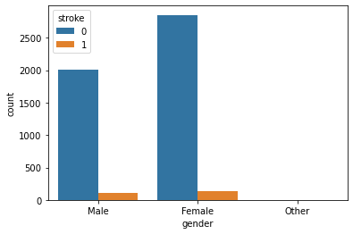

```python
#the association for non-numeric variables...#
sns.countplot(x = 'gender', hue = 'stroke', data = strokedata)
```

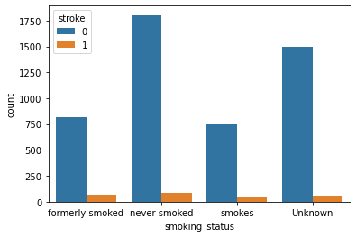

```python
sns.countplot(x = 'smoking_status', hue = 'stroke', data = strokedata)
```

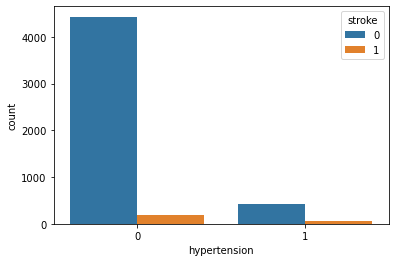

```python
sns.countplot(x = 'hypertension', hue = 'stroke', data = strokedata)
```

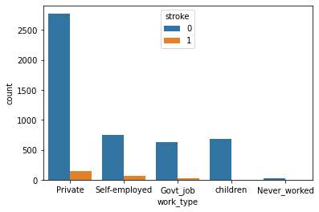

```python
sns.countplot(x = 'work_type', hue = 'stroke', data = strokedata)
```

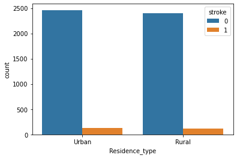

```python
sns.countplot(x = 'Residence_type', hue = 'stroke', data = strokedata)
```

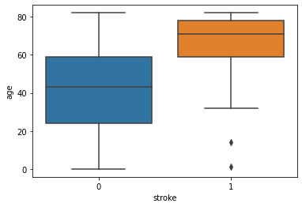

```python
# More EDA for transformations
# Try visualizing stroke incidence by age
sns.boxplot(x = 'stroke', y = 'age', data = strokedata)
```

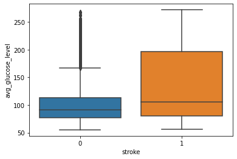

```python
# visualize stroke instances by glucose level
sns.boxplot(x = 'stroke', y = 'avg_glucose_level', data = strokedata)
```

### 1.2 BMI Imputation

*By Cara Chang*

We realized that our data was missing BMI values, and this was too significant to just drop because upon inspection of the distribution of missing values we saw that we lose 40 instances of stroke

```python
strokedata.loc[strokedata['bmi'].isnull()].stroke.value_counts()
```

```
0    161
1     40
Name: stroke, dtype: int64
```

```python
# Create a copy of the bmi column for imputation
strokedata['imputed_bmi'] = strokedata['bmi']
# Create a column that will say if bmi has been imputed or not
strokedata['bmi_original'] = 'no'
strokedata.loc[strokedata['bmi'].isnull(), 'bmi_original'] = 'yes'
strokedata.head()
```

|  | id | gender | age | hypertension | heart_disease | ever_married | work_type | Residence_type | avg_glucose_level | bmi | smoking_status | stroke | imputed_bmi | bmi_original |
| --- | --- | --- | --- | --- | --- | --- | --- | --- | --- | --- | --- | --- | --- | --- |
| 0 | 9046 | Male | 67.0 | 0 | 1 | Yes | Private | Urban | 228.69 | 36.6 | formerly smoked | 1 | 36.6 | no |
| 1 | 51676 | Female | 61.0 | 0 | 0 | Yes | Self-employed | Rural | 202.21 | NaN | never smoked | 1 | NaN | yes |
| 2 | 31112 | Male | 80.0 | 0 | 1 | Yes | Private | Rural | 105.92 | 32.5 | never smoked | 1 | 32.5 | no |
| 3 | 60182 | Female | 49.0 | 0 | 0 | Yes | Private | Urban | 171.23 | 34.4 | smokes | 1 | 34.4 | no |
| 4 | 1665 | Female | 79.0 | 1 | 0 | Yes | Self-employed | Rural | 174.12 | 24.0 | never smoked | 1 | 24.0 | no |

```python
#Considering numeric columns in the data to use KNN
num_cols = [2, 8, 12] # age and avg_glucose_level and imputed_bmi

#Create an object of type MinMaxScaler
scaler = sk.preprocessing.MinMaxScaler()

#Use the object method 'fit_transform' to scale the values to a standard uniform distribution
scaled_data = pd.DataFrame(scaler.fit_transform(strokedata.iloc[:,num_cols]))
```

```python
#Imputing missing values with KNNImputer

#Define an object of type KNNImputer
imputer = impute.KNNImputer(n_neighbors=3, weights="uniform")

#Use the object method 'fit_transform' to impute missing values
imputed_arr = imputer.fit_transform(scaled_data)

#Scaling back the scaled array to obtain the data at the original scale

#Use the object method 'inverse_transform' to scale back the values to the original scale of the data
unscaled_data = scaler.inverse_transform(imputed_arr)

#Note the method imputes the missing value of all the columns
#However, we are interested in imputing the missing values of only the 'imputed_bmi' column

strokedata.loc[:,'imputed_bmi'] = unscaled_data[:,2]
```

```python
# Check that we imputed the values

strokedata['imputed_bmi'].isnull().sum()
```

```
0
```

### 1.3 Splitting the data

```python
#we split the data into a 70-30 split for train and test data
np.random.seed(2)
train = strokedata.sample(round(strokedata.shape[0]*0.7))
test = strokedata.drop(train.index)
```

### 1.4 Creating Dummy Variables

*By Rakin Hussain*

```python
#create a new dataframe that dummies all categorical variables
traind = pd.get_dummies(train)
traind.head()
testd = strokedata.drop(traind.index)
testd = pd.get_dummies(testd)
print(testd.shape)
print(traind.shape)
testd.head()
```

```
(1533, 25)
(3577, 26)
```

|  | id | age | hypertension | heart_disease | avg_glucose_level | bmi | stroke | imputed_bmi | gender_Female | gender_Male | ... | work_type_Self-employed | work_type_children | Residence_type_Rural | Residence_type_Urban | smoking_status_Unknown | smoking_status_formerly smoked | smoking_status_never smoked | smoking_status_smokes | bmi_original_no | bmi_original_yes |
| --- | --- | --- | --- | --- | --- | --- | --- | --- | --- | --- | --- | --- | --- | --- | --- | --- | --- | --- | --- | --- | --- |
| 0 | 9046 | 67.0 | 0 | 1 | 228.69 | 36.6 | 1 | 36.600000 | 0 | 1 | ... | 0 | 0 | 0 | 1 | 0 | 1 | 0 | 0 | 1 | 0 |
| 1 | 51676 | 61.0 | 0 | 0 | 202.21 | NaN | 1 | 32.866667 | 1 | 0 | ... | 1 | 0 | 1 | 0 | 0 | 0 | 1 | 0 | 0 | 1 |
| 7 | 10434 | 69.0 | 0 | 0 | 94.39 | 22.8 | 1 | 22.800000 | 1 | 0 | ... | 0 | 0 | 0 | 1 | 0 | 0 | 1 | 0 | 1 | 0 |
| 10 | 12109 | 81.0 | 1 | 0 | 80.43 | 29.7 | 1 | 29.700000 | 1 | 0 | ... | 0 | 0 | 1 | 0 | 0 | 0 | 1 | 0 | 1 | 0 |
| 12 | 12175 | 54.0 | 0 | 0 | 104.51 | 27.3 | 1 | 27.300000 | 1 | 0 | ... | 0 | 0 | 0 | 1 | 0 | 0 | 0 | 1 | 1 | 0 |

5 rows × 25 columns

### 1.5 Binning Glucose Level

*By Allen Zhang*

```python
#creating bins for glucose levels; the levels are hardcoded by number to represent abnormally/normally high or low sugar levels
binned_glucose = pd.cut(traind['avg_glucose_level'], bins=[50,140,160,180,200,220,240,260,280],retbins = True) # 8 bins, 9 limits
traind['glucose_level_binned'] = binned_glucose[0]
binned_glucose = pd.cut(train['avg_glucose_level'], bins=[50,140,160,180,200,220,240,260,280],retbins = True) # 8 bins, 9 limits
train['glucose_level_binned'] = binned_glucose[0]
binned_glucose = pd.cut(test['avg_glucose_level'], bins=[50,140,160,180,200,220,240,260,280],retbins = True) # 8 bins, 9 limits
test['glucose_level_binned'] = binned_glucose[0]
```

```python
#Finding percentage of people having diabetes in each Age bin
avg_glucose_data = traind.groupby('glucose_level_binned')['stroke'].agg([('stroke_percent','mean'),('nobs','count')]).reset_index(drop=False)
avg_glucose_data
```

|  | glucose_level_binned | stroke_percent | nobs |
| --- | --- | --- | --- |
| 0 | (50, 140] | 0.036642 | 3002 |
| 1 | (140, 160] | 0.019048 | 105 |
| 2 | (160, 180] | 0.160714 | 56 |
| 3 | (180, 200] | 0.155963 | 109 |
| 4 | (200, 220] | 0.083333 | 168 |
| 5 | (220, 240] | 0.101010 | 99 |
| 6 | (240, 260] | 0.225806 | 31 |
| 7 | (260, 280] | 0.142857 | 7 |

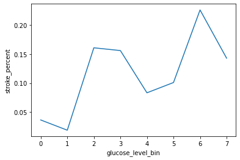

```python
sns.lineplot(x = avg_glucose_data.index, y= avg_glucose_data['stroke_percent'])
plt.xlabel('glucose_level_bin')
```

### 1.6 Binning Age (excluded from model)

*By Cara Chang*

```python
#we also tried to bin age, which seemed like it would be helpful at first but we decided not to use it in the end
binned_age = pd.qcut(traind['age'], 10, retbins = True) # 9 bins, 10 limits
traind['age_binned'] = binned_age[0]
```

```python
#Finding percentage of people having diabetes in each Age bin
age_data = traind.groupby('age_binned')['stroke'].agg([('stroke_percent','mean'),('nobs','count')]).reset_index(drop=False)
age_data
```

|  | age_binned | stroke_percent | nobs |
| --- | --- | --- | --- |
| 0 | (0.079, 11.0] | 0.000000 | 379 |
| 1 | (11.0, 21.0] | 0.000000 | 367 |
| 2 | (21.0, 30.0] | 0.000000 | 343 |
| 3 | (30.0, 38.0] | 0.005291 | 378 |
| 4 | (38.0, 45.0] | 0.011019 | 363 |
| 5 | (45.0, 52.0] | 0.029891 | 368 |
| 6 | (52.0, 58.0] | 0.062678 | 351 |
| 7 | (58.0, 65.0] | 0.066474 | 346 |
| 8 | (65.0, 75.0] | 0.114846 | 357 |
| 9 | (75.0, 82.0] | 0.206154 | 325 |

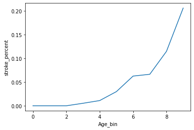

```python
# Visualize percentages

sns.lineplot(x = age_data.index, y= age_data['stroke_percent'])
plt.xlabel('Age_bin')
```

Age was approximately linear, and when we tried transforming age even with a quadratic term (as it looks slightly quadratic), we did not have a good improvement of fit.

### 1.7 Helper Functions

*By Rakin Hussain*

```python
#helper functions

#variable transformations
def var_transform(data):
    duration_binned = pd.qcut(train['duration'], 8, retbins = True)
    bins = duration_binned[1]
    data['duration_binned'] = pd.cut(data['duration'], bins = bins)
    return data

#jitter the values
def jitter(values,j):
    return values + np.random.normal(j,0.02,values.shape)

#Function to compute confusion matrix and prediction accuracy on training data
def confusion_matrix_train(model,cutoff=0.5):
    # Confusion matrix
    cm_df = pd.DataFrame(model.pred_table(threshold = cutoff))
    #Formatting the confusion matrix
    cm_df.columns = ['Predicted 0', 'Predicted 1']
    cm_df = cm_df.rename(index={0: 'Actual 0',1: 'Actual 1'})
    cm = np.array(cm_df)
    # Calculate the accuracy
    accuracy = (cm[0,0]+cm[1,1])/cm.sum()
    sns.heatmap(cm_df, annot=True, cmap='Blues', fmt='g')
    plt.ylabel("Actual Values")
    plt.xlabel("Predicted Values")
    print("Classification accuracy = {:.1%}".format(accuracy))

#Function to compute confusion matrix and prediction accuracy on test data
#Function to compute confusion matrix and prediction accuracy on test data
def confusion_matrix_test(data,actual_values,model,cutoff=0.5):
#Predict the values using the Logit model
    pred_values = model.predict(data)
# Specify the bins
    bins=np.array([0,cutoff,1])
#Confusion matrix
    cm = np.histogram2d(actual_values, pred_values, bins=bins)[0]
    cm_df = pd.DataFrame(cm)
    cm_df.columns = ['Predicted 0','Predicted 1']
    cm_df = cm_df.rename(index={0: 'Actual 0',1:'Actual 1'})
    accuracy = (cm[0,0]+cm[1,1])/cm.sum()
    sns.heatmap(cm_df, annot=True, cmap='Blues', fmt='g')
    plt.ylabel("Actual Values")
    plt.xlabel("Predicted Values")
    print("Classification accuracy = {:.1%}".format(accuracy))

#Function to compute confusion matrix and prediction accuracy on test/train data
def confusion_matrix_data(data,actual_values,model,cutoff=0.5):
#Predict the values using the Logit model
    pred_values = model.predict(data)
# Specify the bins
    bins=np.array([0,cutoff,1])
#Confusion matrix
    cm = np.histogram2d(actual_values, pred_values, bins=bins)[0]
    cm_df = pd.DataFrame(cm)
    cm_df.columns = ['Predicted 0','Predicted 1']
    cm_df = cm_df.rename(index={0: 'Actual 0',1:'Actual 1'})
# Calculate the accuracy
    accuracy = (cm[0,0]+cm[1,1])/cm.sum()
    fnr = (cm[1,0])/(cm[1,0]+cm[1,1])
    precision = (cm[1,1])/(cm[0,1]+cm[1,1])
    fpr = (cm[0,1])/(cm[0,0]+cm[0,1])
    tpr = (cm[1,1])/(cm[1,0]+cm[1,1])
    f1 = 2*(precision*tpr) / (precision + tpr)
    fpr_roc, tpr_roc, auc_thresholds = roc_curve(actual_values, pred_values)
    auc_value = (auc(fpr_roc, tpr_roc))# AUC of ROC
    sns.heatmap(cm_df, annot=True, cmap='Blues', fmt='g')
    plt.ylabel("Actual Values")
    plt.xlabel("Predicted Values")
    print("Classification accuracy = {:.1%}".format(accuracy))
    print("Precision = {:.1%}".format(precision))
    print("TPR or Recall = {:.1%}".format(tpr))
    print("FNR = {:.1%}".format(fnr))
    print("FPR = {:.1%}".format(fpr))
    print("ROC-AUC = {:.1%}".format(auc_value))
    print("F1 = " + str(f1))

#plotting roc
def plot_roc_curve(fpr, tpr, label=None):
    plt.figure(figsize=(8,8))
    plt.title('ROC Curve')
    plt.plot(fpr, tpr, linewidth=2, label=label)
    plt.plot([0, 1], [0, 1], 'k--')
    plt.axis([-0.005, 1, 0, 1.005])
    plt.xticks(np.arange(0,1, 0.05), rotation=90)
    plt.xlabel("False Positive Rate")
    plt.ylabel("True Positive Rate (Recall)")
```

```python
from sklearn.metrics import precision_recall_curve
y = train.stroke # True response values
#ypred = logit_model.predict(train) # predicted response values

#to call:
#p, r, thresholds = precision_recall_curve(y, ypred)

def plot_precision_recall_vs_threshold(precisions, recalls, thresholds):
    plt.figure(figsize=(8, 8))
    plt.title("Precision and Recall Scores as a function of the decision threshold")
    plt.plot(thresholds, precisions[:-1], "b--", label="Precision")
    plt.plot(thresholds, recalls[:-1], "g-", label="Recall")
    plt.ylabel("Score")
    plt.xlabel("Decision Threshold")
    plt.legend(loc='best')
    plt.legend()
# to call:
# plot_precision_recall_vs_threshold(p, r, thresholds)
```

### 1.8 VIF

*By Rakin Hussain*

```python
#setting up VIF
predictors = ['age', 'hypertension', 'heart_disease', 'avg_glucose_level',
           'imputed_bmi', 'gender_Female', 'gender_Male',
       'gender_Other', 'ever_married_No', 'ever_married_Yes',
       'work_type_Govt_job', 'work_type_Never_worked', 'work_type_Private',
       'work_type_Self-employed', 'work_type_children', 'Residence_type_Rural',
       'Residence_type_Urban', 'smoking_status_Unknown',
       'smoking_status_formerly smoked', 'smoking_status_never smoked',
       'smoking_status_smokes']
X = traind[predictors]

from statsmodels.stats.outliers_influence import variance_inflation_factor
from statsmodels.tools.tools import add_constant

X = add_constant(X)
vif_data = pd.DataFrame()
vif_data["feature"] = X.columns

for i in range(len(X.columns)):
    vif_data.loc[i,'VIF'] = variance_inflation_factor(X.values, i)

print(vif_data)
```

```
                           feature       VIF
0                            const  0.000000
1                              age  2.834028
2                     hypertension  1.117608
3                    heart_disease  1.114110
4                avg_glucose_level  1.105810
5                      imputed_bmi  1.326531
6                    gender_Female       inf
7                      gender_Male       inf
8                     gender_Other       inf
9                  ever_married_No       inf
10                ever_married_Yes       inf
11              work_type_Govt_job       inf
12          work_type_Never_worked       inf
13               work_type_Private       inf
14         work_type_Self-employed       inf
15              work_type_children       inf
16            Residence_type_Rural       inf
17            Residence_type_Urban       inf
18          smoking_status_Unknown       inf
19  smoking_status_formerly smoked       inf
20     smoking_status_never smoked       inf
21           smoking_status_smokes       inf
```

All of the collinear variables are due to associations between dummy categories.

## 2 Developing the model

Put code with comments. The comments should explain the code such that it can be easily understood. You may put text *(in a markdown cell)* before a large chunk of code to explain the overall purpose of the code, if it is not intuitive. **Put the name of the person / persons who contributed to each code chunk / set of code chunks.**

### 2.1 Lasso Selection

*By Rakin Hussain*

```python
#helper function
from sklearn.linear_model import Ridge, RidgeCV, Lasso, LassoCV
from sklearn.preprocessing import StandardScaler
from sklearn.metrics import r2_score

y=traind.stroke

#Standardizing predictors so that each of them have zero mean and unit variance

#Defining a scaler object
scalerr = StandardScaler()

#The scaler object will contain the mean and variance of each column (predictor) of X.
#These values will be useful to scale test data based on the same mean and variance as obtained on train data
scalerr.fit(X)

#Using the scaler object (or the values of mean and variance stored in it) to standardize X (or train data)
Xstd = scalerr.transform(X)

#Creating a range of values of the tuning parameter to visualize the lasso coefficients
#for different values of the tuning parameter
alphas = 10**np.linspace(10,-2,100)*0.1

#Finding the lasso coefficients for increasing values of the tuning parameter
lasso = Lasso(max_iter = 10000)
coefs = []

for a in alphas:
    lasso.set_params(alpha=a)
    lasso.fit(Xstd, y)
    coefs.append(lasso.coef_)
```

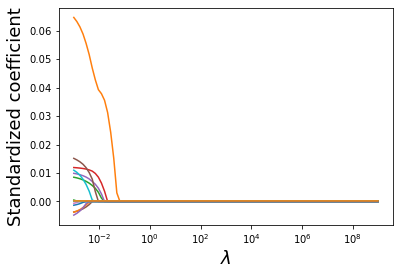

```python
#Visualizing the shrinkage in lasso coefficients with increasing values of the tuning parameter lambda
plt.xlabel('xlabel', fontsize=18)
plt.ylabel('ylabel', fontsize=18)
plt.plot(alphas, coefs)
plt.xscale('log')
plt.xlabel('$\lambda$')
plt.ylabel('Standardized coefficient')
```

```python
#Let us use cross validation to find the optimal value of the tuning parameter - lambda
#For the optimal lambda, the cross validation error will be the least

#Note that we are reducing the range of alpha so as to better visualize the minimum
alphas = 10**np.linspace(-1,-5,200)*0.5
lassocv = LassoCV(alphas = alphas, cv = 10, max_iter = 100000)
lassocv.fit(Xstd, y)

#Optimal value of the tuning parameter - lamda
lassocv.alpha_
```

```
0.0013524798652315671
```

The 10-fold cross validation error minimizes at lambda = 0.001.

```python
#Checking the coefficients of the lasso model
lasso.coef_

for i in range(21):
    print(predictors[i], lasso.coef_[i])
```

```
age 0.0
hypertension 0.06460924103525655
heart_disease 0.008508993748070272
avg_glucose_level 0.011912393576721554
imputed_bmi 0.009882927519591083
gender_Female -0.0037011625476134785
gender_Male 0.0
gender_Other -0.0
ever_married_No -0.0
ever_married_Yes 0.01097416616524748
work_type_Govt_job -2.607177357241072e-18
work_type_Never_worked -0.0037589564148674892
work_type_Private 0.0005058317560568095
work_type_Self-employed 0.0
work_type_children -0.004789842558510318
Residence_type_Rural 0.015140352243811559
Residence_type_Urban -0.0006642707692392022
smoking_status_Unknown 3.724539081772961e-19
smoking_status_formerly smoked 0.0
smoking_status_never smoked 3.4218982966500313e-05
smoking_status_smokes -0.0013247454159403718
```

[All of the zeroed variables would be removed according to LASSO] Going forward, we would have to implement a group lasso technique to account for the dummy variables. We cannot feasibly remove specific categories within dummies. However, this is beyond the scope of the class, so we will proceed with all of the variables. (We will not eliminate age due to academic research suggesting that age is a target indicator for stroke).

### 2.2 Fitting the Initial Model

*By Cara Chang and Amanda Tsuetaki*

```
Optimization terminated successfully.
         Current function value: 0.153034
         Iterations 9
```

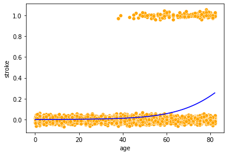

```python
# Include jitter for better visualization of the distribution of 1s and 0s
def jitter(values,j=0):
    return values + np.random.normal(j,0.02,values.shape)

sns.scatterplot(x = jitter(train.age), y = jitter(train.stroke), data = train, color = 'orange')
logit_model = sm.logit(formula = 'stroke~age', data = train).fit()
sns.lineplot(x = 'age', y= logit_model.predict(train), data = train, color = 'blue')
```

```python
logit_model.summary()
```

Logit Regression Results

| Dep. Variable: | stroke | No. Observations: | 3577 |
| --- | --- | --- | --- |
| Model: | Logit | Df Residuals: | 3575 |
| Method: | MLE | Df Model: | 1 |
| Date: | Mon, 13 Mar 2023 | Pseudo R-squ.: | 0.1995 |
| Time: | 21:26:50 | Log-Likelihood: | -547.40 |
| converged: | True | LL-Null: | -683.80 |
| Covariance Type: | nonrobust | LLR p-value: | 2.803e-61 |

|  | coef | std err | z | P>\|z\| | [0.025 | 0.975] |
| --- | --- | --- | --- | --- | --- | --- |
| Intercept | -7.5734 | 0.429 | -17.670 | 0.000 | -8.413 | -6.733 |
| age | 0.0793 | 0.006 | 12.711 | 0.000 | 0.067 | 0.092 |

```python
(np.exp(0.0793)-1)*100
```

```
8.25290320710006
```

The coefficient of age is 0.0793, which means for a unit increase in age, the log odds of stroke likeliness increase by 0.0793, or the odds increases by 8.25%.

Assuming a significance level of 𝛼=0.05 , age seems to be a staistically variable as its p-value and the model’s overall LLR p-value are less than our 𝛼 level.

Print out the correlations for each of the continuous variables to check for possible interactions.

```python
corr_table = train.corr()
corr_table
```

|  | id | age | hypertension | heart_disease | avg_glucose_level | bmi | stroke | imputed_bmi |
| --- | --- | --- | --- | --- | --- | --- | --- | --- |
| id | 1.000000 | -0.014804 | 0.001437 | 0.005596 | -0.029385 | -0.003362 | -0.004766 | -0.007601 |
| age | -0.014804 | 1.000000 | 0.272511 | 0.266071 | 0.226338 | 0.340309 | 0.248097 | 0.338419 |
| hypertension | 0.001437 | 0.272511 | 1.000000 | 0.108822 | 0.169636 | 0.171667 | 0.117325 | 0.166541 |
| heart_disease | 0.005596 | 0.266071 | 0.108822 | 1.000000 | 0.150224 | 0.049623 | 0.137965 | 0.049233 |
| avg_glucose_level | -0.029385 | 0.226338 | 0.169636 | 0.150224 | 1.000000 | 0.178433 | 0.116067 | 0.182748 |
| bmi | -0.003362 | 0.340309 | 0.171667 | 0.049623 | 0.178433 | 1.000000 | 0.046985 | 1.000000 |
| stroke | -0.004766 | 0.248097 | 0.117325 | 0.137965 | 0.116067 | 0.046985 | 1.000000 | 0.044624 |
| imputed_bmi | -0.007601 | 0.338419 | 0.166541 | 0.049233 | 0.182748 | 1.000000 | 0.044624 | 1.000000 |

BMI and age have a correlations of 0.340309 that might be worth looking into as an interaction term. To test this, train a basic model using all of the continuous variables and then add in the interaction term.

```python
# basic model with all the continuous vars
logit_model = sm.logit(formula = 'stroke~imputed_bmi+avg_glucose_level+age+hypertension', data = train).fit()
logit_model.summary()
```

```
Optimization terminated successfully.
         Current function value: 0.151553
         Iterations 9
```

Logit Regression Results

| Dep. Variable: | stroke | No. Observations: | 3577 |
| --- | --- | --- | --- |
| Model: | Logit | Df Residuals: | 3572 |
| Method: | MLE | Df Model: | 4 |
| Date: | Mon, 13 Mar 2023 | Pseudo R-squ.: | 0.2072 |
| Time: | 21:26:50 | Log-Likelihood: | -542.10 |
| converged: | True | LL-Null: | -683.80 |
| Covariance Type: | nonrobust | LLR p-value: | 4.149e-60 |

|  | coef | std err | z | P>\|z\| | [0.025 | 0.975] |
| --- | --- | --- | --- | --- | --- | --- |
| Intercept | -8.1115 | 0.637 | -12.732 | 0.000 | -9.360 | -6.863 |
| imputed_bmi | 0.0072 | 0.013 | 0.533 | 0.594 | -0.019 | 0.034 |
| avg_glucose_level | 0.0034 | 0.001 | 2.389 | 0.017 | 0.001 | 0.006 |
| age | 0.0768 | 0.007 | 11.764 | 0.000 | 0.064 | 0.090 |
| hypertension | 0.3211 | 0.199 | 1.616 | 0.106 | -0.068 | 0.711 |

BMI does not appear to be statistically significant in this model, to test for the interaction, add an interaction term between BMI and age.

```python
#new model adding an interaction between bmi and age
logit_model2 = sm.logit(formula = 'stroke~imputed_bmi+I(imputed_bmi*age)+avg_glucose_level+age', data = train).fit()
logit_model2.summary()
```

```
Optimization terminated successfully.
         Current function value: 0.151543
         Iterations 9
```

Logit Regression Results

| Dep. Variable: | stroke | No. Observations: | 3577 |
| --- | --- | --- | --- |
| Model: | Logit | Df Residuals: | 3572 |
| Method: | MLE | Df Model: | 4 |
| Date: | Mon, 13 Mar 2023 | Pseudo R-squ.: | 0.2073 |
| Time: | 21:33:25 | Log-Likelihood: | -542.07 |
| converged: | True | LL-Null: | -683.80 |
| Covariance Type: | nonrobust | LLR p-value: | 4.005e-60 |

|  | coef | std err | z | P>\|z\| | [0.025 | 0.975] |
| --- | --- | --- | --- | --- | --- | --- |
| Intercept | -10.5468 | 1.420 | -7.427 | 0.000 | -13.330 | -7.764 |
| imputed_bmi | 0.0848 | 0.042 | 2.033 | 0.042 | 0.003 | 0.167 |
| I(imputed_bmi * age) | -0.0012 | 0.001 | -1.833 | 0.067 | -0.003 | 8.52e-05 |
| avg_glucose_level | 0.0039 | 0.001 | 2.723 | 0.006 | 0.001 | 0.007 |
| age | 0.1152 | 0.022 | 5.324 | 0.000 | 0.073 | 0.158 |

```
Classification accuracy = 75.0%
Precision = 12.2%
TPR or Recall = 78.8%
FNR = 21.2%
FPR = 25.2%
ROC-AUC = 85.1%
F1 = 0.21081576535288726
```

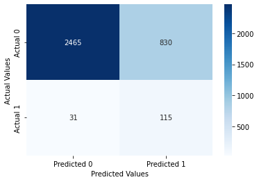

```python
confusion_matrix_data(train.dropna(),train.dropna().stroke,logit_model,cutoff=0.05)
```

```
Classification accuracy = 74.7%
Precision = 12.2%
TPR or Recall = 80.1%
FNR = 19.9%
FPR = 25.5%
ROC-AUC = 84.9%
F1 = 0.21214868540344517
```

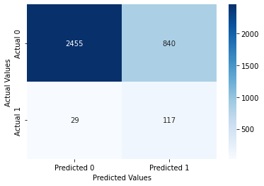

```python
confusion_matrix_data(train.dropna(),train.dropna().stroke,logit_model2,cutoff=0.05)
```

```python
# add hypertension
logit_model3 = sm.logit(formula = 'stroke~imputed_bmi+I(imputed_bmi*age)+avg_glucose_level+age+hypertension', data = train).fit()
logit_model3.summary()
```

```
Optimization terminated successfully.
         Current function value: 0.151199
         Iterations 9
```

Logit Regression Results

| Dep. Variable: | stroke | No. Observations: | 3577 |
| --- | --- | --- | --- |
| Model: | Logit | Df Residuals: | 3571 |
| Method: | MLE | Df Model: | 5 |
| Date: | Mon, 13 Mar 2023 | Pseudo R-squ.: | 0.2091 |
| Time: | 21:26:51 | Log-Likelihood: | -540.84 |
| converged: | True | LL-Null: | -683.80 |
| Covariance Type: | nonrobust | LLR p-value: | 1.068e-59 |

|  | coef | std err | z | P>\|z\| | [0.025 | 0.975] |
| --- | --- | --- | --- | --- | --- | --- |
| Intercept | -10.3732 | 1.398 | -7.418 | 0.000 | -13.114 | -7.632 |
| imputed_bmi | 0.0810 | 0.041 | 1.977 | 0.048 | 0.001 | 0.161 |
| I(imputed_bmi * age) | -0.0012 | 0.001 | -1.814 | 0.070 | -0.002 | 9.64e-05 |
| avg_glucose_level | 0.0036 | 0.001 | 2.529 | 0.011 | 0.001 | 0.006 |
| age | 0.1128 | 0.021 | 5.289 | 0.000 | 0.071 | 0.155 |
| hypertension | 0.3168 | 0.199 | 1.595 | 0.111 | -0.072 | 0.706 |

```
Classification accuracy = 74.5%
Precision = 11.8%
TPR or Recall = 76.2%
FNR = 23.8%
FPR = 25.6%
ROC-AUC = 83.6%
F1 = 0.2038216560509554
```

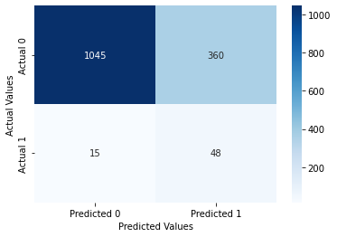

```python
confusion_matrix_data(test.dropna(),test.dropna().stroke,logit_model3,cutoff=0.05)
```

```python
# add glucose_level_binned
logit_model4 = sm.logit(formula = 'stroke~imputed_bmi+I(imputed_bmi*age)+age+hypertension+glucose_level_binned', data = train).fit()
logit_model4.summary()
```

```
Optimization terminated successfully.
         Current function value: 0.149123
         Iterations 9
```

Logit Regression Results

| Dep. Variable: | stroke | No. Observations: | 3577 |
| --- | --- | --- | --- |
| Model: | Logit | Df Residuals: | 3565 |
| Method: | MLE | Df Model: | 11 |
| Date: | Mon, 13 Mar 2023 | Pseudo R-squ.: | 0.2199 |
| Time: | 21:26:51 | Log-Likelihood: | -533.41 |
| converged: | True | LL-Null: | -683.80 |
| Covariance Type: | nonrobust | LLR p-value: | 6.032e-58 |

|  | coef | std err | z | P>\|z\| | [0.025 | 0.975] |
| --- | --- | --- | --- | --- | --- | --- |
| Intercept | -10.1102 | 1.379 | -7.333 | 0.000 | -12.812 | -7.408 |
| glucose_level_binned[T.Interval(140, 160, closed='right')] | -0.6163 | 0.737 | -0.837 | 0.403 | -2.060 | 0.827 |
| glucose_level_binned[T.Interval(160, 180, closed='right')] | 1.3561 | 0.422 | 3.217 | 0.001 | 0.530 | 2.182 |
| glucose_level_binned[T.Interval(180, 200, closed='right')] | 0.9186 | 0.303 | 3.031 | 0.002 | 0.325 | 1.513 |
| glucose_level_binned[T.Interval(200, 220, closed='right')] | 0.0129 | 0.310 | 0.041 | 0.967 | -0.595 | 0.621 |
| glucose_level_binned[T.Interval(220, 240, closed='right')] | 0.2282 | 0.365 | 0.625 | 0.532 | -0.487 | 0.943 |
| glucose_level_binned[T.Interval(240, 260, closed='right')] | 1.1012 | 0.468 | 2.351 | 0.019 | 0.183 | 2.019 |
| glucose_level_binned[T.Interval(260, 280, closed='right')] | 0.5902 | 1.115 | 0.529 | 0.597 | -1.595 | 2.775 |
| imputed_bmi | 0.0814 | 0.041 | 2.008 | 0.045 | 0.002 | 0.161 |
| I(imputed_bmi * age) | -0.0012 | 0.001 | -1.787 | 0.074 | -0.002 | 0.000 |
| age | 0.1126 | 0.021 | 5.313 | 0.000 | 0.071 | 0.154 |
| hypertension | 0.2654 | 0.202 | 1.315 | 0.189 | -0.130 | 0.661 |

```
Classification accuracy = 76.0%
Precision = 12.3%
TPR or Recall = 74.6%
FNR = 25.4%
FPR = 23.9%
ROC-AUC = 83.1%
F1 = 0.21076233183856502
```

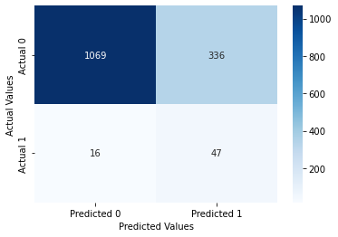

```python
confusion_matrix_data(test.dropna(),test.dropna().stroke,logit_model4,cutoff=0.05)
```

### 2.3 Search for potential interaction terms

*By Cara Chang*

```
model number 0
                            OLS Regression Results
==============================================================================
Dep. Variable:                 stroke   R-squared:                       0.075
Model:                            OLS   Adj. R-squared:                  0.072
Method:                 Least Squares   F-statistic:                     23.15
Date:                Mon, 13 Mar 2023   Prob (F-statistic):           3.08e-50
Time:                        21:26:51   Log-Likelihood:                 762.70
No. Observations:                3441   AIC:                            -1499.
Df Residuals:                    3428   BIC:                            -1420.
Df Model:                          12
Covariance Type:            nonrobust
==============================================================================================================================
                                                                 coef    std err          t      P>|t|      [0.025      0.975]
------------------------------------------------------------------------------------------------------------------------------
Intercept                                                      0.0140      0.025      0.572      0.568      -0.034       0.062
glucose_level_binned[T.Interval(140, 160, closed='right')]    -0.0138      0.019     -0.712      0.476      -0.052       0.024
glucose_level_binned[T.Interval(160, 180, closed='right')]     0.0802      0.027      2.938      0.003       0.027       0.134
glucose_level_binned[T.Interval(180, 200, closed='right')]     0.0733      0.020      3.599      0.000       0.033       0.113
glucose_level_binned[T.Interval(200, 220, closed='right')]     0.0135      0.017      0.803      0.422      -0.019       0.046
glucose_level_binned[T.Interval(220, 240, closed='right')]     0.0217      0.021      1.034      0.301      -0.019       0.063
glucose_level_binned[T.Interval(240, 260, closed='right')]     0.1587      0.036      4.348      0.000       0.087       0.230
glucose_level_binned[T.Interval(260, 280, closed='right')]     0.0665      0.080      0.835      0.404      -0.090       0.223
bmi                                                           -0.0012      0.000     -2.398      0.017      -0.002      -0.000
I(imputed_bmi * age)                                        3.776e-05   2.23e-05      1.696      0.090    -5.9e-06    8.14e-05
age                                                            0.0009      0.001      1.422      0.155      -0.000       0.002
hypertension                                                   0.1357      0.046      2.930      0.003       0.045       0.226
imputed_bmi                                                   -0.0012      0.000     -2.398      0.017      -0.002      -0.000
hypertension:imputed_bmi                                      -0.0028      0.001     -2.067      0.039      -0.005      -0.000
==============================================================================
Omnibus:                     2815.118   Durbin-Watson:                   1.998
Prob(Omnibus):                  0.000   Jarque-Bera (JB):            46138.110
Skew:                           4.034   Prob(JB):                         0.00
Kurtosis:                      19.022   Cond. No.                     9.13e+17
==============================================================================

Notes:
[1] Standard Errors assume that the covariance matrix of the errors is correctly specified.
[2] The smallest eigenvalue is 9.41e-27. This might indicate that there are
strong multicollinearity problems or that the design matrix is singular.
```

[output cut: 88 more lines]

```
Kurtosis:                      19.043   Cond. No.                     2.87e+16
==============================================================================

Notes:
[1] Standard Errors assume that the covariance matrix of the errors is correctly specified.
[2] The smallest eigenvalue is 1.93e-23. This might indicate that there are
strong multicollinearity problems or that the design matrix is singular.
Classification accuracy = 53.3%
Precision = 9.8%
TPR or Recall = 87.1%
FNR = 12.9%
FPR = 48.7%
ROC-AUC = 82.1%
F1 = 0.176759410801964
model number 3
```

```
                            OLS Regression Results
==============================================================================
Dep. Variable:                 stroke   R-squared:                       0.090
Model:                            OLS   Adj. R-squared:                  0.086
Method:                 Least Squares   F-statistic:                     18.89
Date:                Mon, 13 Mar 2023   Prob (F-statistic):           3.40e-58
Time:                        21:26:52   Log-Likelihood:                 791.67
No. Observations:                3441   AIC:                            -1545.
Df Residuals:                    3422   BIC:                            -1429.
Df Model:                          18
Covariance Type:            nonrobust
===========================================================================================================================================
                                                                              coef    std err          t      P>|t|      [0.025      0.975]
-------------------------------------------------------------------------------------------------------------------------------------------
Intercept                                                                   0.0171      0.024      0.703      0.482      -0.031       0.065
glucose_level_binned[T.Interval(140, 160, closed='right')]                 -0.0057      0.020     -0.283      0.778      -0.045       0.034
glucose_level_binned[T.Interval(160, 180, closed='right')]                  0.0438      0.032      1.390      0.165      -0.018       0.106
glucose_level_binned[T.Interval(180, 200, closed='right')]                  0.0814      0.023      3.524      0.000       0.036       0.127
glucose_level_binned[T.Interval(200, 220, closed='right')]                  0.0265      0.019      1.412      0.158      -0.010       0.063
glucose_level_binned[T.Interval(220, 240, closed='right')]                  0.0511      0.024      2.160      0.031       0.005       0.098
glucose_level_binned[T.Interval(240, 260, closed='right')]                  0.0245      0.041      0.591      0.555      -0.057       0.106
glucose_level_binned[T.Interval(260, 280, closed='right')]                 -0.0546      0.136     -0.400      0.689      -0.322       0.213
bmi                                                                        -0.0025      0.001     -2.588      0.010      -0.004      -0.001
I(imputed_bmi * age)                                                      3.12e-05   2.19e-05      1.423      0.155   -1.18e-05    7.42e-05
age                                                                         0.0011      0.001      1.841      0.066   -7.06e-05       0.002
hypertension                                                                0.0442      0.014      3.076      0.002       0.016       0.072
hypertension:glucose_level_binned[T.Interval(140, 160, closed='right')]    -0.0974      0.072     -1.347      0.178      -0.239       0.044
hypertension:glucose_level_binned[T.Interval(160, 180, closed='right')]     0.1366      0.062      2.208      0.027       0.015       0.258
hypertension:glucose_level_binned[T.Interval(180, 200, closed='right')]    -0.0313      0.047     -0.658      0.511      -0.124       0.062
hypertension:glucose_level_binned[T.Interval(200, 220, closed='right')]    -0.0553      0.040     -1.389      0.165      -0.133       0.023
hypertension:glucose_level_binned[T.Interval(220, 240, closed='right')]    -0.1221      0.049     -2.486      0.013      -0.218      -0.026
hypertension:glucose_level_binned[T.Interval(240, 260, closed='right')]     0.5602      0.085      6.603      0.000       0.394       0.727
hypertension:glucose_level_binned[T.Interval(260, 280, closed='right')]     0.1812      0.168      1.082      0.280      -0.147       0.510
==============================================================================
Omnibus:                     2832.920   Durbin-Watson:                   2.000
Prob(Omnibus):                  0.000   Jarque-Bera (JB):            48613.102
Skew:                           4.050   Prob(JB):                         0.00
Kurtosis:                      19.537   Cond. No.                     9.47e+04
==============================================================================

```

[output cut: 45 more lines]

```
Kurtosis:                      18.961   Cond. No.                     9.13e+17
==============================================================================

Notes:
[1] Standard Errors assume that the covariance matrix of the errors is correctly specified.
[2] The smallest eigenvalue is 9.42e-27. This might indicate that there are
strong multicollinearity problems or that the design matrix is singular.
Classification accuracy = 54.6%
Precision = 10.0%
TPR or Recall = 85.5%
FNR = 14.5%
FPR = 47.3%
ROC-AUC = 83.1%
F1 = 0.1793570219966159
model number 5
```

```
                            OLS Regression Results
==============================================================================
Dep. Variable:                 stroke   R-squared:                       0.083
Model:                            OLS   Adj. R-squared:                  0.079
Method:                 Least Squares   F-statistic:                     23.78
Date:                Mon, 13 Mar 2023   Prob (F-statistic):           1.33e-55
Time:                        21:26:52   Log-Likelihood:                 777.25
No. Observations:                3441   AIC:                            -1526.
Df Residuals:                    3427   BIC:                            -1440.
Df Model:                          13
Covariance Type:            nonrobust
==============================================================================================================================
                                                                 coef    std err          t      P>|t|      [0.025      0.975]
------------------------------------------------------------------------------------------------------------------------------
Intercept                                                      0.0140      0.024      0.573      0.567      -0.034       0.062
glucose_level_binned[T.Interval(140, 160, closed='right')]    -0.0144      0.019     -0.746      0.456      -0.052       0.023
glucose_level_binned[T.Interval(160, 180, closed='right')]     0.0807      0.027      2.970      0.003       0.027       0.134
glucose_level_binned[T.Interval(180, 200, closed='right')]     0.0751      0.020      3.698      0.000       0.035       0.115
glucose_level_binned[T.Interval(200, 220, closed='right')]     0.0040      0.017      0.241      0.810      -0.029       0.037
glucose_level_binned[T.Interval(220, 240, closed='right')]     0.0168      0.021      0.801      0.423      -0.024       0.058
glucose_level_binned[T.Interval(240, 260, closed='right')]     0.1473      0.036      4.047      0.000       0.076       0.219
glucose_level_binned[T.Interval(260, 280, closed='right')]     0.0633      0.079      0.797      0.426      -0.092       0.219
bmi                                                           -0.0021      0.001     -2.183      0.029      -0.004      -0.000
I(imputed_bmi * age)                                        2.874e-05    2.2e-05      1.306      0.192   -1.44e-05    7.19e-05
age                                                            0.0009      0.001      1.545      0.122      -0.000       0.002
hypertension                                                   0.0406      0.012      3.385      0.001       0.017       0.064
heart_disease                                                 -0.2194      0.089     -2.463      0.014      -0.394      -0.045
heart_disease:age                                              0.0043      0.001      3.356      0.001       0.002       0.007
==============================================================================
Omnibus:                     2798.867   Durbin-Watson:                   2.004
Prob(Omnibus):                  0.000   Jarque-Bera (JB):            45885.157
Skew:                           3.998   Prob(JB):                         0.00
Kurtosis:                      19.003   Cond. No.                     4.08e+04
==============================================================================

Notes:
[1] Standard Errors assume that the covariance matrix of the errors is correctly specified.
[2] The condition number is large, 4.08e+04. This might indicate that there are
strong multicollinearity or other numerical problems.
Classification accuracy = 56.5%
```

[output cut: 95 more lines]

```
Kurtosis:                      19.253   Cond. No.                     9.90e+04
==============================================================================

Notes:
[1] Standard Errors assume that the covariance matrix of the errors is correctly specified.
[2] The condition number is large, 9.9e+04. This might indicate that there are
strong multicollinearity or other numerical problems.
Classification accuracy = 54.1%
Precision = 9.6%
TPR or Recall = 83.6%
FNR = 16.4%
FPR = 47.7%
ROC-AUC = 81.1%
F1 = 0.17142857142857143
model number 8
```

```
                            OLS Regression Results
==============================================================================
Dep. Variable:                 stroke   R-squared:                       0.074
Model:                            OLS   Adj. R-squared:                  0.070
Method:                 Least Squares   F-statistic:                     21.07
Date:                Mon, 13 Mar 2023   Prob (F-statistic):           8.24e-49
Time:                        21:26:53   Log-Likelihood:                 760.93
No. Observations:                3441   AIC:                            -1494.
Df Residuals:                    3427   BIC:                            -1408.
Df Model:                          13
Covariance Type:            nonrobust
==============================================================================================================================
                                                                 coef    std err          t      P>|t|      [0.025      0.975]
------------------------------------------------------------------------------------------------------------------------------
Intercept                                                      0.0274      0.027      0.996      0.319      -0.027       0.081
glucose_level_binned[T.Interval(140, 160, closed='right')]    -0.0134      0.019     -0.688      0.491      -0.051       0.025
glucose_level_binned[T.Interval(160, 180, closed='right')]     0.0809      0.027      2.961      0.003       0.027       0.134
glucose_level_binned[T.Interval(180, 200, closed='right')]     0.0738      0.020      3.617      0.000       0.034       0.114
glucose_level_binned[T.Interval(200, 220, closed='right')]     0.0135      0.017      0.802      0.423      -0.019       0.046
glucose_level_binned[T.Interval(220, 240, closed='right')]     0.0224      0.021      1.066      0.286      -0.019       0.064
glucose_level_binned[T.Interval(240, 260, closed='right')]     0.1593      0.037      4.363      0.000       0.088       0.231
glucose_level_binned[T.Interval(260, 280, closed='right')]     0.0673      0.080      0.844      0.399      -0.089       0.224
Residence_type[T.Urban]                                       -0.0212      0.026     -0.823      0.411      -0.072       0.029
bmi                                                           -0.0014      0.001     -2.721      0.007      -0.002      -0.000
I(imputed_bmi * age)                                        3.132e-05   2.21e-05      1.418      0.156    -1.2e-05    7.46e-05
age                                                            0.0011      0.001      1.843      0.065   -6.98e-05       0.002
hypertension                                                   0.0433      0.012      3.595      0.000       0.020       0.067
imputed_bmi                                                   -0.0014      0.001     -2.721      0.007      -0.002      -0.000
Residence_type[T.Urban]:imputed_bmi                            0.0007      0.001      0.865      0.387      -0.001       0.002
==============================================================================
Omnibus:                     2816.930   Durbin-Watson:                   2.001
Prob(Omnibus):                  0.000   Jarque-Bera (JB):            46191.901
Skew:                           4.038   Prob(JB):                         0.00
Kurtosis:                      19.030   Cond. No.                     9.12e+17
==============================================================================

Notes:
[1] Standard Errors assume that the covariance matrix of the errors is correctly specified.
[2] The smallest eigenvalue is 9.43e-27. This might indicate that there are
strong multicollinearity problems or that the design matrix is singular.
```

[output cut: 82 more lines]

```
Residence_type[T.Urban]:age                                   -0.0011      0.001     -0.957      0.339      -0.003       0.001
hypertension                                                   0.0432      0.012      3.589      0.000       0.020       0.067
bmi:age                                                     8.081e-06   1.58e-05      0.513      0.608   -2.28e-05     3.9e-05
Residence_type[T.Urban]:bmi:age                             2.996e-05   4.33e-05      0.692      0.489   -5.49e-05       0.000
==============================================================================
Omnibus:                     2815.379   Durbin-Watson:                   2.001
Prob(Omnibus):                  0.000   Jarque-Bera (JB):            46123.701
Skew:                           4.035   Prob(JB):                         0.00
Kurtosis:                      19.018   Cond. No.                     2.34e+16
==============================================================================

Notes:
[1] Standard Errors assume that the covariance matrix of the errors is correctly specified.
[2] The smallest eigenvalue is 3.28e-23. This might indicate that there are
strong multicollinearity problems or that the design matrix is singular.
```

```
Classification accuracy = 50.7%
Precision = 9.7%
TPR or Recall = 90.3%
FNR = 9.7%
FPR = 51.7%
ROC-AUC = 83.1%
F1 = 0.1755485893416928
model number 11
                            OLS Regression Results
==============================================================================
Dep. Variable:                 stroke   R-squared:                       0.076
Model:                            OLS   Adj. R-squared:                  0.071
Method:                 Least Squares   F-statistic:                     14.86
Date:                Mon, 13 Mar 2023   Prob (F-statistic):           1.10e-46
Time:                        21:26:54   Log-Likelihood:                 765.07
No. Observations:                3441   AIC:                            -1490.
Df Residuals:                    3421   BIC:                            -1367.
Df Model:                          19
Covariance Type:            nonrobust
======================================================================================================================================================
                                                                                         coef    std err          t      P>|t|      [0.025      0.975]
------------------------------------------------------------------------------------------------------------------------------------------------------
Intercept                                                                              0.0170      0.025      0.684      0.494      -0.032       0.066
glucose_level_binned[T.Interval(140, 160, closed='right')]                            -0.0245      0.028     -0.886      0.376      -0.079       0.030
glucose_level_binned[T.Interval(160, 180, closed='right')]                             0.1166      0.036      3.246      0.001       0.046       0.187
glucose_level_binned[T.Interval(180, 200, closed='right')]                             0.0957      0.028      3.364      0.001       0.040       0.152
glucose_level_binned[T.Interval(200, 220, closed='right')]                            -0.0193      0.023     -0.838      0.402      -0.065       0.026
glucose_level_binned[T.Interval(220, 240, closed='right')]                             0.0188      0.028      0.672      0.502      -0.036       0.073
glucose_level_binned[T.Interval(240, 260, closed='right')]                             0.1632      0.056      2.889      0.004       0.052       0.274
glucose_level_binned[T.Interval(260, 280, closed='right')]                             0.0887      0.087      1.014      0.311      -0.083       0.260
Residence_type[T.Urban]                                                               -0.0008      0.007     -0.115      0.908      -0.015       0.013
Residence_type[T.Urban]:glucose_level_binned[T.Interval(140, 160, closed='right')]     0.0224      0.039      0.578      0.564      -0.054       0.099
Residence_type[T.Urban]:glucose_level_binned[T.Interval(160, 180, closed='right')]    -0.0847      0.055     -1.538      0.124      -0.193       0.023
Residence_type[T.Urban]:glucose_level_binned[T.Interval(180, 200, closed='right')]    -0.0442      0.040     -1.103      0.270      -0.123       0.034
Residence_type[T.Urban]:glucose_level_binned[T.Interval(200, 220, closed='right')]     0.0680      0.033      2.089      0.037       0.004       0.132
Residence_type[T.Urban]:glucose_level_binned[T.Interval(220, 240, closed='right')]     0.0082      0.041      0.198      0.843      -0.073       0.089
Residence_type[T.Urban]:glucose_level_binned[T.Interval(240, 260, closed='right')]    -0.0057      0.074     -0.078      0.938      -0.150       0.139
Residence_type[T.Urban]:glucose_level_binned[T.Interval(260, 280, closed='right')]    -0.1311      0.213     -0.615      0.539      -0.549       0.287
bmi                                                                                   -0.0025      0.001     -2.568      0.010      -0.004      -0.001
I(imputed_bmi * age)                                                                3.062e-05   2.21e-05      1.385      0.166   -1.27e-05     7.4e-05
```

[output cut: 50 more lines]

```
imputed_bmi                                                   -0.0015      0.001     -2.838      0.005      -0.003      -0.000
smoking_status[T.formerly smoked]:imputed_bmi                  0.0014      0.001      0.954      0.340      -0.002       0.004
smoking_status[T.never smoked]:imputed_bmi                     0.0019      0.001      1.650      0.099      -0.000       0.004
smoking_status[T.smokes]:imputed_bmi                           0.0020      0.001      1.396      0.163      -0.001       0.005
==============================================================================
Omnibus:                     2814.218   Durbin-Watson:                   1.997
Prob(Omnibus):                  0.000   Jarque-Bera (JB):            46064.662
Skew:                           4.033   Prob(JB):                         0.00
Kurtosis:                      19.007   Cond. No.                     6.67e+17
==============================================================================

Notes:
[1] Standard Errors assume that the covariance matrix of the errors is correctly specified.
[2] The smallest eigenvalue is 1.76e-26. This might indicate that there are
strong multicollinearity problems or that the design matrix is singular.
```

```
Classification accuracy = 50.1%
Precision = 9.7%
TPR or Recall = 90.3%
FNR = 9.7%
FPR = 52.3%
ROC-AUC = 83.4%
F1 = 0.17445482866043616
model number 13
                            OLS Regression Results
==============================================================================
Dep. Variable:                 stroke   R-squared:                       0.078
Model:                            OLS   Adj. R-squared:                  0.074
Method:                 Least Squares   F-statistic:                     17.11
Date:                Mon, 13 Mar 2023   Prob (F-statistic):           1.63e-49
Time:                        21:26:55   Log-Likelihood:                 768.98
No. Observations:                3441   AIC:                            -1502.
Df Residuals:                    3423   BIC:                            -1391.
Df Model:                          17
Covariance Type:            nonrobust
==============================================================================================================================
                                                                 coef    std err          t      P>|t|      [0.025      0.975]
------------------------------------------------------------------------------------------------------------------------------
Intercept                                                      0.0024      0.025      0.095      0.925      -0.046       0.051
glucose_level_binned[T.Interval(140, 160, closed='right')]    -0.0121      0.019     -0.623      0.533      -0.050       0.026
glucose_level_binned[T.Interval(160, 180, closed='right')]     0.0830      0.027      3.043      0.002       0.030       0.137
glucose_level_binned[T.Interval(180, 200, closed='right')]     0.0733      0.020      3.596      0.000       0.033       0.113
glucose_level_binned[T.Interval(200, 220, closed='right')]     0.0130      0.017      0.773      0.439      -0.020       0.046
glucose_level_binned[T.Interval(220, 240, closed='right')]     0.0205      0.021      0.977      0.329      -0.021       0.062
glucose_level_binned[T.Interval(240, 260, closed='right')]     0.1566      0.036      4.292      0.000       0.085       0.228
glucose_level_binned[T.Interval(260, 280, closed='right')]     0.0619      0.080      0.777      0.437      -0.094       0.218
smoking_status[T.formerly smoked]                             -0.0466      0.029     -1.617      0.106      -0.103       0.010
smoking_status[T.never smoked]                                -0.0581      0.018     -3.223      0.001      -0.093      -0.023
smoking_status[T.smokes]                                      -0.0770      0.028     -2.743      0.006      -0.132      -0.022
bmi                                                           -0.0008      0.001     -0.768      0.443      -0.003       0.001
I(imputed_bmi * age)                                        9.343e-07   2.37e-05      0.039      0.969   -4.56e-05    4.74e-05
age                                                            0.0011      0.001      1.815      0.070   -9.05e-05       0.002
smoking_status[T.formerly smoked]:age                          0.0011      0.001      2.055      0.040    5.08e-05       0.002
smoking_status[T.never smoked]:age                             0.0013      0.000      3.429      0.001       0.001       0.002
smoking_status[T.smokes]:age                                   0.0018      0.001      3.124      0.002       0.001       0.003
hypertension                                                   0.0385      0.012      3.177      0.002       0.015       0.062
```

[output cut: 54 more lines]

```
bmi:age                                                    -5.476e-06   1.89e-05     -0.290      0.772   -4.25e-05    3.15e-05
smoking_status[T.formerly smoked]:bmi:age                    3.07e-05   7.79e-05      0.394      0.694      -0.000       0.000
smoking_status[T.never smoked]:bmi:age                      1.778e-05   5.66e-05      0.314      0.753   -9.31e-05       0.000
smoking_status[T.smokes]:bmi:age                           -9.289e-06   8.29e-05     -0.112      0.911      -0.000       0.000
==============================================================================
Omnibus:                     2802.313   Durbin-Watson:                   2.002
Prob(Omnibus):                  0.000   Jarque-Bera (JB):            45526.193
Skew:                           4.010   Prob(JB):                         0.00
Kurtosis:                      18.912   Cond. No.                     3.88e+15
==============================================================================

Notes:
[1] Standard Errors assume that the covariance matrix of the errors is correctly specified.
[2] The smallest eigenvalue is 1.18e-21. This might indicate that there are
strong multicollinearity problems or that the design matrix is singular.
```

```
Classification accuracy = 53.0%
Precision = 10.1%
TPR or Recall = 91.8%
FNR = 8.2%
FPR = 49.3%
ROC-AUC = 83.1%
F1 = 0.18241042345276873
model number 15
                            OLS Regression Results
==============================================================================
Dep. Variable:                 stroke   R-squared:                       0.091
Model:                            OLS   Adj. R-squared:                  0.082
Method:                 Least Squares   F-statistic:                     10.06
Date:                Mon, 13 Mar 2023   Prob (F-statistic):           1.08e-49
Time:                        21:26:56   Log-Likelihood:                 793.32
No. Observations:                3441   AIC:                            -1517.
Df Residuals:                    3406   BIC:                            -1302.
Df Model:                          34
Covariance Type:            nonrobust
================================================================================================================================================================
                                                                                                   coef    std err          t      P>|t|      [0.025      0.975]
----------------------------------------------------------------------------------------------------------------------------------------------------------------
Intercept                                                                                        0.0132      0.025      0.537      0.591      -0.035       0.062
glucose_level_binned[T.Interval(140, 160, closed='right')]                                       0.0046      0.033      0.139      0.889      -0.061       0.070
glucose_level_binned[T.Interval(160, 180, closed='right')]                                       0.0614      0.061      0.999      0.318      -0.059       0.182
glucose_level_binned[T.Interval(180, 200, closed='right')]                                      -0.0014      0.047     -0.029      0.977      -0.094       0.092
glucose_level_binned[T.Interval(200, 220, closed='right')]                                       0.0250      0.044      0.566      0.571      -0.061       0.111
glucose_level_binned[T.Interval(220, 240, closed='right')]                                      -0.0821      0.065     -1.262      0.207      -0.210       0.045
glucose_level_binned[T.Interval(240, 260, closed='right')]                                      -0.0846      0.097     -0.872      0.383      -0.275       0.106
glucose_level_binned[T.Interval(260, 280, closed='right')]                                       0.1743      0.066      2.653      0.008       0.045       0.303
smoking_status[T.formerly smoked]                                                               -0.0081      0.012     -0.676      0.499      -0.032       0.015
smoking_status[T.never smoked]                                                                  -0.0085      0.009     -0.905      0.365      -0.027       0.010
smoking_status[T.smokes]                                                                        -0.0120      0.012     -1.023      0.306      -0.035       0.011
smoking_status[T.formerly smoked]:glucose_level_binned[T.Interval(140, 160, closed='right')]    -0.0126      0.055     -0.229      0.819      -0.121       0.096
smoking_status[T.never smoked]:glucose_level_binned[T.Interval(140, 160, closed='right')]       -0.0280      0.047     -0.596      0.552      -0.120       0.064
smoking_status[T.smokes]:glucose_level_binned[T.Interval(140, 160, closed='right')]             -0.0453      0.062     -0.730      0.465      -0.167       0.076
smoking_status[T.formerly smoked]:glucose_level_binned[T.Interval(160, 180, closed='right')]     0.1437      0.087      1.649      0.099      -0.027       0.314
smoking_status[T.never smoked]:glucose_level_binned[T.Interval(160, 180, closed='right')]       -0.0116      0.075     -0.154      0.878      -0.159       0.136
smoking_status[T.smokes]:glucose_level_binned[T.Interval(160, 180, closed='right')]             -0.0141      0.083     -0.169      0.866      -0.178       0.150
smoking_status[T.formerly smoked]:glucose_level_binned[T.Interval(180, 200, closed='right')]     0.1442      0.066      2.173      0.030       0.014       0.274
```

[output cut: 21 more lines]

```
Skew:                           3.998   Prob(JB):                         0.00
Kurtosis:                      19.060   Cond. No.                     1.16e+16
==============================================================================

Notes:
[1] Standard Errors assume that the covariance matrix of the errors is correctly specified.
[2] The smallest eigenvalue is 5.82e-23. This might indicate that there are
strong multicollinearity problems or that the design matrix is singular.
Classification accuracy = 51.3%
Precision = 9.4%
TPR or Recall = 85.2%
FNR = 14.8%
FPR = 50.8%
ROC-AUC = 81.3%
F1 = 0.1691056910569106
```

[figure not shown]

```python
#we thought there might be more interaction terms, especially with categorical variables
potential_interaction_cat = ['hypertension', 'heart_disease', 'Residence_type', 'smoking_status']
quantitative_interaction = ['imputed_bmi', 'age', 'bmi*age', 'glucose_level_binned']
formula_list = []
i = 0
# look for possible interactions with categorical variables
for categorical_var in potential_interaction_cat:
    for quantitative_var in quantitative_interaction:
        var0 = categorical_var
        var1 = quantitative_var
        model_formula = 'stroke~bmi+I(imputed_bmi*age)+age+hypertension+glucose_level_binned+' + '+'.join([var0+"*"+var1])
        formula_list.append(model_formula)
        print("model number " + str(i))
        model = sm.ols(formula = model_formula, data=train).fit()
        print(model.summary())
        confusion_matrix_data(test.dropna(),test.dropna().stroke,model,cutoff=0.05)
        i = i + 1
```

```python
# Looking closer at models that gave an F1 greater than 0.18
print(formula_list[5])
print(formula_list[6])
print(formula_list[14])
```

```
stroke~bmi+I(imputed_bmi*age)+age+hypertension+glucose_level_binned+heart_disease*age
stroke~bmi+I(imputed_bmi*age)+age+hypertension+glucose_level_binned+heart_disease*bmi*age
stroke~bmi+I(imputed_bmi*age)+age+hypertension+glucose_level_binned+smoking_status*bmi*age
```

Only the 5th formula worked, as the other formulas had too many iterations to retrieve.

```python
#new model using the newly found interactions
logit_model5 = sm.logit(formula = formula_list[5], data = train).fit()
logit_model5.summary()
```

```
Optimization terminated successfully.
         Current function value: 0.136899
         Iterations 10
```

Logit Regression Results

| Dep. Variable: | stroke | No. Observations: | 3441 |
| --- | --- | --- | --- |
| Model: | Logit | Df Residuals: | 3427 |
| Method: | MLE | Df Model: | 13 |
| Date: | Mon, 13 Mar 2023 | Pseudo R-squ.: | 0.2203 |
| Time: | 21:26:57 | Log-Likelihood: | -471.07 |
| converged: | True | LL-Null: | -604.20 |
| Covariance Type: | nonrobust | LLR p-value: | 2.647e-49 |

|  | coef | std err | z | P>\|z\| | [0.025 | 0.975] |
| --- | --- | --- | --- | --- | --- | --- |
| Intercept | -10.2653 | 1.340 | -7.662 | 0.000 | -12.891 | -7.639 |
| glucose_level_binned[T.Interval(140, 160, closed='right')] | -0.5320 | 0.738 | -0.721 | 0.471 | -1.979 | 0.915 |
| glucose_level_binned[T.Interval(160, 180, closed='right')] | 1.2979 | 0.469 | 2.767 | 0.006 | 0.379 | 2.217 |
| glucose_level_binned[T.Interval(180, 200, closed='right')] | 0.9011 | 0.329 | 2.738 | 0.006 | 0.256 | 1.546 |
| glucose_level_binned[T.Interval(200, 220, closed='right')] | 0.1119 | 0.328 | 0.341 | 0.733 | -0.531 | 0.755 |
| glucose_level_binned[T.Interval(220, 240, closed='right')] | 0.2305 | 0.387 | 0.596 | 0.551 | -0.528 | 0.989 |
| glucose_level_binned[T.Interval(240, 260, closed='right')] | 1.2368 | 0.484 | 2.558 | 0.011 | 0.289 | 2.184 |
| glucose_level_binned[T.Interval(260, 280, closed='right')] | 0.7335 | 1.149 | 0.638 | 0.523 | -1.518 | 2.985 |
| bmi | 0.0888 | 0.038 | 2.349 | 0.019 | 0.015 | 0.163 |
| I(imputed_bmi * age) | -0.0013 | 0.001 | -2.064 | 0.039 | -0.003 | -6.51e-05 |
| age | 0.1119 | 0.021 | 5.354 | 0.000 | 0.071 | 0.153 |
| hypertension | 0.4128 | 0.213 | 1.938 | 0.053 | -0.005 | 0.830 |
| heart_disease | 1.3987 | 1.855 | 0.754 | 0.451 | -2.237 | 5.034 |
| heart_disease:age | -0.0123 | 0.026 | -0.481 | 0.630 | -0.062 | 0.038 |

```
Classification accuracy = 78.5%
Precision = 13.8%
TPR or Recall = 76.2%
FNR = 23.8%
FPR = 21.4%
ROC-AUC = 83.8%
F1 = 0.23357664233576642
```

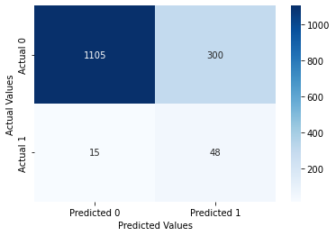

```python
confusion_matrix_data(test.dropna(),test.dropna().stroke,logit_model5,cutoff=0.05)
```

### 2.4 Forward Selection and Forward Selection with 2nd order interactions

*By Rakin Hussain*

```python
#setting up forward selection
traind.rename(columns = {'smoking_status_formerly smoked':'smoking_status_formerly_smoked',
                         'smoking_status_never smoked':'smoking_status_never_smoked'}, inplace = True)

testd.rename(columns = {'smoking_status_formerly smoked':'smoking_status_formerly_smoked',
                         'smoking_status_never smoked':'smoking_status_never_smoked'}, inplace = True)
```

```python
X = traind[['age', 'hypertension', 'heart_disease', 'avg_glucose_level',
           'imputed_bmi', 'ever_married_No', 'ever_married_Yes', 'Residence_type_Rural',
       'Residence_type_Urban', 'smoking_status_Unknown',
       'smoking_status_formerly_smoked', 'smoking_status_never_smoked',
       'smoking_status_smokes']]

X_backup = traind[['age', 'hypertension', 'heart_disease', 'avg_glucose_level',
           'imputed_bmi', 'ever_married_No', 'ever_married_Yes',
       'Residence_type_Rural',
       'Residence_type_Urban', 'smoking_status_Unknown',
       'smoking_status_formerly_smoked', 'smoking_status_never_smoked',
       'smoking_status_smokes']]
```

```python
import warnings
warnings.filterwarnings("ignore")

for combo in itertools.combinations(X_backup.columns, 2):
    traind['_'.join(combo)] = traind[combo[0]]*traind[combo[1]] # Creating int. terms
    testd['_'.join(combo)] = testd[combo[0]]*testd[combo[1]] # Creating int. terms
    X.loc[:,'_'.join(combo)] = traind.loc[:,'_'.join(combo)] # Creating the same X
```

```python
def processSubset(predictor_subset):
    # Fit model on feature_set and calculate R-squared
    model = sm.ols('stroke~' + '+'.join(predictor_subset),data = traind).fit()
    Rsquared = model.rsquared
    return {"model":model, "Rsquared":Rsquared}

#Function to find the best predictor out of p-k predictors and add it to the model containing the k predictors
def forward(predictors):

    # Pull out predictors we still need to process
    remaining_predictors = [p for p in X.columns if p not in predictors]

    tic = time.time()

    results = []

    for p in remaining_predictors:
        results.append(processSubset(predictors+[p]))

    # Wrap everything up in a nice dataframe
    models = pd.DataFrame(results)

    # Choose the model with the highest RSS
    best_model = models.loc[models['Rsquared'].argmax()]

    toc = time.time()
    print("Processed ", models.shape[0], "models on", len(predictors)+1, "predictors in", (toc-tic), "seconds.")

    # Return the best model, along with some other useful information about the model
    return best_model

def forward_selection():
    models_best = pd.DataFrame(columns=["Rsquared", "model"]) # start with empty df
    tic = time.time()
    predictors = []
    for i in range(1,len(X.columns)+1):
        models_best.loc[i] = forward(predictors)
        predictors = list(models_best.loc[i]["model"].params.index[1:])
    toc = time.time()
    print("Total elapsed time:", (toc-tic), "seconds.")
    return models_best

models_best = forward_selection()
```

```
Processed  91 models on 1 predictors in 0.8417577743530273 seconds.
Processed  90 models on 2 predictors in 1.2755730152130127 seconds.
Processed  89 models on 3 predictors in 1.5524132251739502 seconds.
Processed  88 models on 4 predictors in 1.054762840270996 seconds.
Processed  87 models on 5 predictors in 1.3203859329223633 seconds.
Processed  86 models on 6 predictors in 1.612860918045044 seconds.
Processed  85 models on 7 predictors in 2.466768980026245 seconds.
Processed  84 models on 8 predictors in 3.1777772903442383 seconds.
Processed  83 models on 9 predictors in 2.2325329780578613 seconds.
Processed  82 models on 10 predictors in 3.164466381072998 seconds.
Processed  81 models on 11 predictors in 3.251134157180786 seconds.
Processed  80 models on 12 predictors in 3.622121810913086 seconds.
Processed  79 models on 13 predictors in 7.369401931762695 seconds.
Processed  78 models on 14 predictors in 3.2302560806274414 seconds.
Processed  77 models on 15 predictors in 2.3153162002563477 seconds.
Processed  76 models on 16 predictors in 2.9364359378814697 seconds.
Processed  75 models on 17 predictors in 3.680635929107666 seconds.
Processed  74 models on 18 predictors in 2.951052188873291 seconds.
Processed  73 models on 19 predictors in 3.345128297805786 seconds.
Processed  72 models on 20 predictors in 3.657400131225586 seconds.
Processed  71 models on 21 predictors in 5.33042311668396 seconds.
Processed  70 models on 22 predictors in 4.35394811630249 seconds.
Processed  69 models on 23 predictors in 5.042509078979492 seconds.
Processed  68 models on 24 predictors in 3.725980043411255 seconds.
Processed  67 models on 25 predictors in 4.178936958312988 seconds.
Processed  66 models on 26 predictors in 4.1247169971466064 seconds.
Processed  65 models on 27 predictors in 5.367777109146118 seconds.
Processed  64 models on 28 predictors in 4.206923007965088 seconds.
Processed  63 models on 29 predictors in 4.489058017730713 seconds.
Processed  62 models on 30 predictors in 5.340817213058472 seconds.
Processed  61 models on 31 predictors in 5.972868204116821 seconds.
Processed  60 models on 32 predictors in 4.843114137649536 seconds.
Processed  59 models on 33 predictors in 5.714613199234009 seconds.
Processed  58 models on 34 predictors in 5.478318214416504 seconds.
Processed  57 models on 35 predictors in 4.777346134185791 seconds.
Processed  56 models on 36 predictors in 5.5853331089019775 seconds.
Processed  55 models on 37 predictors in 5.068240165710449 seconds.
Processed  54 models on 38 predictors in 5.441167116165161 seconds.
Processed  53 models on 39 predictors in 5.774413108825684 seconds.
Processed  52 models on 40 predictors in 5.05317497253418 seconds.
```

[output cut: 37 more lines]

```
Processed  14 models on 78 predictors in 3.0698421001434326 seconds.
Processed  13 models on 79 predictors in 4.406261920928955 seconds.
Processed  12 models on 80 predictors in 3.1041369438171387 seconds.
Processed  11 models on 81 predictors in 1.9580762386322021 seconds.
Processed  10 models on 82 predictors in 2.2737579345703125 seconds.
Processed  9 models on 83 predictors in 2.92598295211792 seconds.
Processed  8 models on 84 predictors in 2.2984321117401123 seconds.
Processed  7 models on 85 predictors in 1.7722270488739014 seconds.
Processed  6 models on 86 predictors in 1.2588989734649658 seconds.
Processed  5 models on 87 predictors in 0.9049983024597168 seconds.
Processed  4 models on 88 predictors in 0.9360628128051758 seconds.
Processed  3 models on 89 predictors in 0.5962600708007812 seconds.
Processed  2 models on 90 predictors in 0.43764615058898926 seconds.
Processed  1 models on 91 predictors in 0.23636698722839355 seconds.
Total elapsed time: 382.52810502052307 seconds.
```

```
8
```

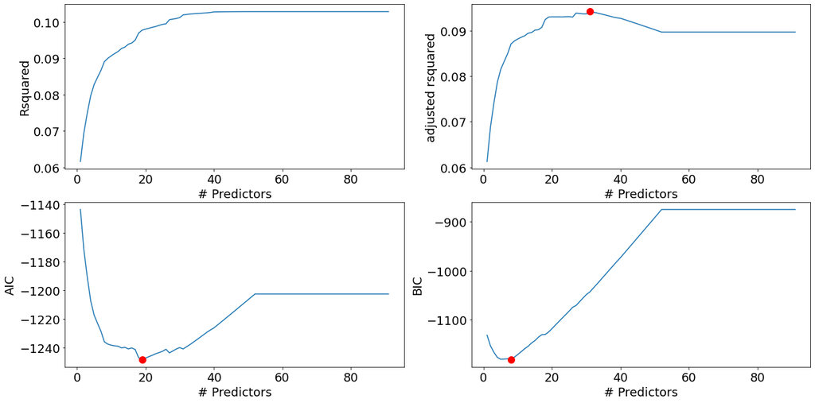

```python
def best_sub_plots():
    plt.figure(figsize=(20,10))
    plt.rcParams.update({'font.size': 18, 'lines.markersize': 10})

    # Set up a 2x2 grid so we can look at 4 plots at once
    plt.subplot(2, 2, 1)

    # We will now plot a red dot to indicate the model with the largest adjusted R^2 statistic.
    # The argmax() function can be used to identify the location of the maximum point of a vector
    plt.plot(models_best["Rsquared"])
    plt.xlabel('# Predictors')
    plt.ylabel('Rsquared')

    # We will now plot a red dot to indicate the model with the largest adjusted R^2 statistic.
    # The argmax() function can be used to identify the location of the maximum point of a vector

    rsquared_adj = models_best.apply(lambda row: row[1].rsquared_adj, axis=1)

    plt.subplot(2, 2, 2)
    plt.plot(rsquared_adj)
    plt.plot(1+rsquared_adj.argmax(), rsquared_adj.max(), "or")
    plt.xlabel('# Predictors')
    plt.ylabel('adjusted rsquared')

    # We'll do the same for AIC and BIC, this time looking for the models with the SMALLEST statistic
    aic = models_best.apply(lambda row: row[1].aic, axis=1)

    plt.subplot(2, 2, 3)
    plt.plot(aic)
    plt.plot(1+aic.argmin(), aic.min(), "or")
    plt.xlabel('# Predictors')
    plt.ylabel('AIC')

    bic = models_best.apply(lambda row: row[1].bic, axis=1)

    plt.subplot(2, 2, 4)
    plt.plot(bic)
    plt.plot(1+bic.argmin(), bic.min(), "or")
    plt.xlabel('# Predictors')
    plt.ylabel('BIC')
    print(1+bic.argmin())
best_sub_plots()
```

```python
#chose 8 from the BIC graph
best_forward = models_best.loc[8,'model']
best_forward.summary()
```

OLS Regression Results

| Dep. Variable: | stroke | R-squared: | 0.089 |
| --- | --- | --- | --- |
| Model: | OLS | Adj. R-squared: | 0.087 |
| Method: | Least Squares | F-statistic: | 43.61 |
| Date: | Mon, 13 Mar 2023 | Prob (F-statistic): | 3.59e-67 |
| Time: | 21:33:22 | Log-Likelihood: | 627.02 |
| No. Observations: | 3577 | AIC: | -1236. |
| Df Residuals: | 3568 | BIC: | -1180. |
| Df Model: | 8 |  |  |
| Covariance Type: | nonrobust |  |  |

|  | coef | std err | t | P>\|t\| | [0.025 | 0.975] |
| --- | --- | --- | --- | --- | --- | --- |
| Intercept | -0.1270 | 0.015 | -8.290 | 0.000 | -0.157 | -0.097 |
| age | 0.0029 | 0.000 | 8.805 | 0.000 | 0.002 | 0.004 |
| heart_disease_smoking_status_smokes | 0.1559 | 0.031 | 5.055 | 0.000 | 0.095 | 0.216 |
| age_avg_glucose_level | 5.214e-06 | 1.32e-06 | 3.949 | 0.000 | 2.63e-06 | 7.8e-06 |
| ever_married_No_smoking_status_Unknown | 0.0392 | 0.017 | 2.267 | 0.023 | 0.005 | 0.073 |
| hypertension_ever_married_No | 0.1463 | 0.038 | 3.862 | 0.000 | 0.072 | 0.220 |
| ever_married_No_smoking_status_never_smoked | 0.0316 | 0.017 | 1.851 | 0.064 | -0.002 | 0.065 |
| age_ever_married_No | -0.0019 | 0.000 | -4.107 | 0.000 | -0.003 | -0.001 |
| ever_married_No | 0.0725 | 0.024 | 3.063 | 0.002 | 0.026 | 0.119 |

| Omnibus: | 2698.513 | Durbin-Watson: | 1.997 |
| --- | --- | --- | --- |
| Prob(Omnibus): | 0.000 | Jarque-Bera (JB): | 35062.378 |
| Skew: | 3.680 | Prob(JB): | 0.00 |
| Kurtosis: | 16.457 | Cond. No. | 6.91e+04 |

Notes:  
[1] Standard Errors assume that the covariance matrix of the errors is correctly specified.  
[2] The condition number is large, 6.91e+04. This might indicate that there are  
strong multicollinearity or other numerical problems.

```python
#creating the model from the forward steps
forward_logit = sm.logit('stroke~age+heart_disease_smoking_status_smokes+age_avg_glucose_level+\
                          ever_married_No_smoking_status_Unknown+hypertension_ever_married_No+\
                          ever_married_No_smoking_status_never_smoked+age_ever_married_No+ever_married_No',
                         data = traind).fit()

forward_logit.summary()
```

```
Optimization terminated successfully.
         Current function value: 0.149222
         Iterations 11
```

Logit Regression Results

| Dep. Variable: | stroke | No. Observations: | 3577 |
| --- | --- | --- | --- |
| Model: | Logit | Df Residuals: | 3568 |
| Method: | MLE | Df Model: | 8 |
| Date: | Mon, 13 Mar 2023 | Pseudo R-squ.: | 0.2194 |
| Time: | 21:33:23 | Log-Likelihood: | -533.77 |
| converged: | True | LL-Null: | -683.80 |
| Covariance Type: | nonrobust | LLR p-value: | 3.998e-60 |

|  | coef | std err | z | P>\|z\| | [0.025 | 0.975] |
| --- | --- | --- | --- | --- | --- | --- |
| Intercept | -7.1670 | 0.491 | -14.588 | 0.000 | -8.130 | -6.204 |
| age | 0.0663 | 0.008 | 8.506 | 0.000 | 0.051 | 0.082 |
| heart_disease_smoking_status_smokes | 1.2488 | 0.375 | 3.326 | 0.001 | 0.513 | 1.985 |
| age_avg_glucose_level | 5.112e-05 | 2.01e-05 | 2.537 | 0.011 | 1.16e-05 | 9.06e-05 |
| ever_married_No_smoking_status_Unknown | 1.0611 | 0.915 | 1.160 | 0.246 | -0.732 | 2.854 |
| hypertension_ever_married_No | 1.5368 | 0.628 | 2.449 | 0.014 | 0.307 | 2.767 |
| ever_married_No_smoking_status_never_smoked | 1.4312 | 0.748 | 1.915 | 0.056 | -0.034 | 2.896 |
| age_ever_married_No | 0.0144 | 0.018 | 0.795 | 0.427 | -0.021 | 0.050 |
| ever_married_No | -2.3922 | 1.398 | -1.711 | 0.087 | -5.133 | 0.348 |

```
Classification accuracy = 74.8%
Precision = 14.1%
TPR or Recall = 75.9%
FNR = 24.1%
FPR = 25.2%
ROC-AUC = 82.3%
F1 = 0.23715415019762845
```

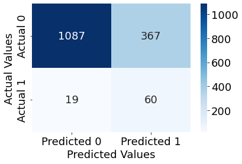

```python
confusion_matrix_data(testd,testd.stroke,forward_logit, cutoff=0.05)
```

### 2.5 Trying Transformation Terms

*By Cara Chang*

```python
#added some transformation terms that were observed from EDA before
logit_model6 = sm.logit(formula = "stroke~imputed_bmi+I(imputed_bmi*age)+age+hypertension+glucose_level_binned+I(age**2)+I(age**3)+I(age*heart_disease*imputed_bmi)+I(imputed_bmi*hypertension)", data = train).fit()
logit_model6.summary()
```

```
Optimization terminated successfully.
         Current function value: 0.147017
         Iterations 13
```

Logit Regression Results

| Dep. Variable: | stroke | No. Observations: | 3577 |
| --- | --- | --- | --- |
| Model: | Logit | Df Residuals: | 3561 |
| Method: | MLE | Df Model: | 15 |
| Date: | Mon, 13 Mar 2023 | Pseudo R-squ.: | 0.2309 |
| Time: | 21:33:23 | Log-Likelihood: | -525.88 |
| converged: | True | LL-Null: | -683.80 |
| Covariance Type: | nonrobust | LLR p-value: | 2.841e-58 |

|  | coef | std err | z | P>\|z\| | [0.025 | 0.975] |
| --- | --- | --- | --- | --- | --- | --- |
| Intercept | -32.4198 | 10.562 | -3.069 | 0.002 | -53.122 | -11.718 |
| glucose_level_binned[T.Interval(140, 160, closed='right')] | -0.6494 | 0.737 | -0.882 | 0.378 | -2.093 | 0.794 |
| glucose_level_binned[T.Interval(160, 180, closed='right')] | 1.3146 | 0.421 | 3.124 | 0.002 | 0.490 | 2.139 |
| glucose_level_binned[T.Interval(180, 200, closed='right')] | 0.9122 | 0.301 | 3.033 | 0.002 | 0.323 | 1.502 |
| glucose_level_binned[T.Interval(200, 220, closed='right')] | -0.0654 | 0.312 | -0.209 | 0.834 | -0.678 | 0.547 |
| glucose_level_binned[T.Interval(220, 240, closed='right')] | 0.1676 | 0.365 | 0.459 | 0.646 | -0.548 | 0.883 |
| glucose_level_binned[T.Interval(240, 260, closed='right')] | 1.0471 | 0.472 | 2.218 | 0.027 | 0.122 | 1.972 |
| glucose_level_binned[T.Interval(260, 280, closed='right')] | 0.5765 | 1.114 | 0.518 | 0.605 | -1.606 | 2.759 |
| imputed_bmi | 0.1199 | 0.070 | 1.712 | 0.087 | -0.017 | 0.257 |
| I(imputed_bmi * age) | -0.0017 | 0.001 | -1.536 | 0.124 | -0.004 | 0.000 |
| age | 1.1896 | 0.525 | 2.268 | 0.023 | 0.161 | 2.218 |
| hypertension | 1.2594 | 0.939 | 1.341 | 0.180 | -0.582 | 3.100 |
| I(age ** 2) | -0.0171 | 0.009 | -1.964 | 0.050 | -0.034 | -3.55e-05 |
| I(age ** 3) | 8.896e-05 | 4.73e-05 | 1.881 | 0.060 | -3.75e-06 | 0.000 |
| I(age * heart_disease * imputed_bmi) | 0.0002 | 0.000 | 2.098 | 0.036 | 1.43e-05 | 0.000 |
| I(imputed_bmi * hypertension) | -0.0324 | 0.030 | -1.085 | 0.278 | -0.091 | 0.026 |

Possibly complete quasi-separation: A fraction 0.26 of observations can be  
perfectly predicted. This might indicate that there is complete  
quasi-separation. In this case some parameters will not be identified.

```
Classification accuracy = 66.9%
Precision = 9.9%
TPR or Recall = 82.5%
FNR = 17.5%
FPR = 33.8%
ROC-AUC = 83.0%
F1 = 0.176271186440678
```

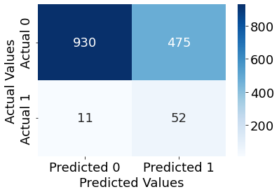

```python
confusion_matrix_data(test.dropna(),test.dropna().stroke,logit_model6,cutoff=0.04)
```

Brute-forcing interactions and transformation terms did not do much to the model fit. We would be better off without transformation terms, as this second-to-last model has a worse FNR and F1 compared to our final model.

```python
# Combining forward selection and categorical variable insights with age transformation terms
logit_model7 = sm.logit('stroke~age+heart_disease_smoking_status_smokes+age_avg_glucose_level+\
                          ever_married_No_smoking_status_Unknown+hypertension_ever_married_No+\
                          ever_married_No_smoking_status_never_smoked+age_ever_married_No+ever_married_No+\
                          imputed_bmi+I(imputed_bmi*age)+I(age * heart_disease * imputed_bmi)+I(age**2)+I(age**3)',
                         data = traind).fit()


logit_model7.summary()
```

```
Optimization terminated successfully.
         Current function value: 0.147459
         Iterations 14
```

Logit Regression Results

| Dep. Variable: | stroke | No. Observations: | 3577 |
| --- | --- | --- | --- |
| Model: | Logit | Df Residuals: | 3563 |
| Method: | MLE | Df Model: | 13 |
| Date: | Mon, 13 Mar 2023 | Pseudo R-squ.: | 0.2286 |
| Time: | 21:33:23 | Log-Likelihood: | -527.46 |
| converged: | True | LL-Null: | -683.80 |
| Covariance Type: | nonrobust | LLR p-value: | 5.335e-59 |

|  | coef | std err | z | P>\|z\| | [0.025 | 0.975] |
| --- | --- | --- | --- | --- | --- | --- |
| Intercept | -34.3702 | 10.764 | -3.193 | 0.001 | -55.468 | -13.272 |
| age | 1.2954 | 0.531 | 2.442 | 0.015 | 0.256 | 2.335 |
| heart_disease_smoking_status_smokes | 1.1717 | 0.430 | 2.722 | 0.006 | 0.328 | 2.015 |
| age_avg_glucose_level | 5.319e-05 | 2.1e-05 | 2.533 | 0.011 | 1.2e-05 | 9.43e-05 |
| ever_married_No_smoking_status_Unknown | 1.1450 | 0.904 | 1.267 | 0.205 | -0.626 | 2.917 |
| hypertension_ever_married_No | 1.4486 | 0.611 | 2.371 | 0.018 | 0.251 | 2.646 |
| ever_married_No_smoking_status_never_smoked | 1.4507 | 0.732 | 1.983 | 0.047 | 0.017 | 2.885 |
| age_ever_married_No | -0.0133 | 0.023 | -0.570 | 0.569 | -0.059 | 0.033 |
| ever_married_No | -0.3883 | 1.699 | -0.228 | 0.819 | -3.719 | 2.942 |
| imputed_bmi | 0.1197 | 0.069 | 1.725 | 0.085 | -0.016 | 0.256 |
| I(imputed_bmi * age) | -0.0018 | 0.001 | -1.656 | 0.098 | -0.004 | 0.000 |
| I(age * heart_disease * imputed_bmi) | 4.199e-05 | 0.000 | 0.348 | 0.728 | -0.000 | 0.000 |
| I(age ** 2) | -0.0190 | 0.009 | -2.164 | 0.030 | -0.036 | -0.002 |
| I(age ** 3) | 9.952e-05 | 4.75e-05 | 2.094 | 0.036 | 6.35e-06 | 0.000 |

Possibly complete quasi-separation: A fraction 0.26 of observations can be  
perfectly predicted. This might indicate that there is complete  
quasi-separation. In this case some parameters will not be identified.

```
Classification accuracy = 60.8%
Precision = 10.6%
TPR or Recall = 88.6%
FNR = 11.4%
FPR = 40.7%
ROC-AUC = 82.5%
F1 = 0.18893387314439944
```

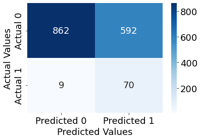

```python
confusion_matrix_data(testd, testd.stroke, logit_model7, cutoff=0.03)
```

### 2.6 Code fitting the final model

Put the code(s) that fit the final model(s) in separate cell(s), i.e., the code with the `.ols()` or `.logit()` functions.

```python
# Combining forward selection and categorical variable insights:
model_final = sm.logit('stroke~age+heart_disease_smoking_status_smokes+age_avg_glucose_level+\
                          ever_married_No_smoking_status_Unknown+hypertension_ever_married_No+\
                          ever_married_No_smoking_status_never_smoked+age_ever_married_No+ever_married_No+\
                          imputed_bmi+I(imputed_bmi*age)+I(age * heart_disease * imputed_bmi)',
                         data = traind).fit()


model_final.summary()
```

```
Optimization terminated successfully.
         Current function value: 0.148885
         Iterations 11
```

Logit Regression Results

| Dep. Variable: | stroke | No. Observations: | 3577 |
| --- | --- | --- | --- |
| Model: | Logit | Df Residuals: | 3565 |
| Method: | MLE | Df Model: | 11 |
| Date: | Mon, 13 Mar 2023 | Pseudo R-squ.: | 0.2212 |
| Time: | 21:33:24 | Log-Likelihood: | -532.56 |
| converged: | True | LL-Null: | -683.80 |
| Covariance Type: | nonrobust | LLR p-value: | 2.639e-58 |

|  | coef | std err | z | P>\|z\| | [0.025 | 0.975] |
| --- | --- | --- | --- | --- | --- | --- |
| Intercept | -9.5082 | 1.441 | -6.598 | 0.000 | -12.333 | -6.684 |
| age | 0.0995 | 0.022 | 4.498 | 0.000 | 0.056 | 0.143 |
| heart_disease_smoking_status_smokes | 1.2047 | 0.433 | 2.782 | 0.005 | 0.356 | 2.053 |
| age_avg_glucose_level | 5.039e-05 | 2.09e-05 | 2.406 | 0.016 | 9.34e-06 | 9.15e-05 |
| ever_married_No_smoking_status_Unknown | 1.0029 | 0.914 | 1.097 | 0.273 | -0.789 | 2.795 |
| hypertension_ever_married_No | 1.4500 | 0.624 | 2.322 | 0.020 | 0.226 | 2.674 |
| ever_married_No_smoking_status_never_smoked | 1.4277 | 0.746 | 1.914 | 0.056 | -0.034 | 2.890 |
| age_ever_married_No | 0.0135 | 0.018 | 0.741 | 0.459 | -0.022 | 0.049 |
| ever_married_No | -2.2909 | 1.410 | -1.625 | 0.104 | -5.055 | 0.473 |
| imputed_bmi | 0.0747 | 0.043 | 1.748 | 0.080 | -0.009 | 0.159 |
| I(imputed_bmi * age) | -0.0011 | 0.001 | -1.548 | 0.122 | -0.002 | 0.000 |
| I(age * heart_disease * imputed_bmi) | 2.568e-05 | 0.000 | 0.213 | 0.831 | -0.000 | 0.000 |

```
Classification accuracy = 64.7%
Precision = 11.5%
TPR or Recall = 87.3%
FNR = 12.7%
FPR = 36.5%
ROC-AUC = 82.2%
F1 = 0.203240058910162
```

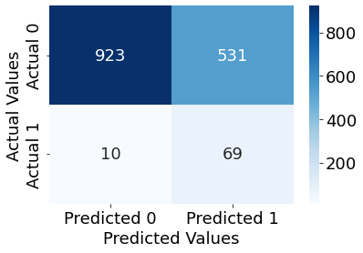

```python
confusion_matrix_data(testd, testd.stroke, model_final, cutoff=0.03)
```

Our final model has an FNR of 12.7% and an F1 of 0.2032. While this is not an ideal F1 score, we had difficulty getting a higher value since selection results required a low cutoff to minimize F1, and we also focused on optimizing different metrics in class. Therefore, we had less practice optimizing F1 score instead of accuracy.